# Diagonal Case

## 8.3 The output from the fit

Here is the fitted spline curve to the number of unmarked fish available in each recovery sample.

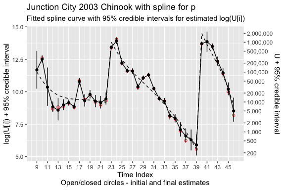

Fitted spline curve with covariate for p

```r
demo4.fit$plots$fit.plot
```

The jump in the spline when hatchery fish are released is evident.

The distribution of the posterior sample for the total number unmarked and total abundance is available as before:

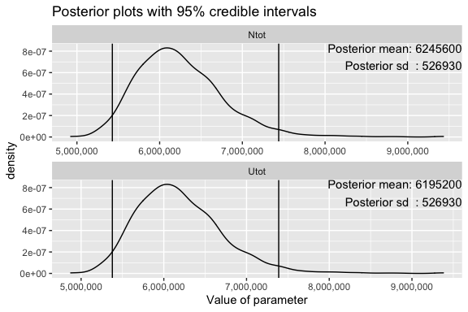

Distribution of posterior samples

```r
demo4.fit$plots$post.UNtot.plot
```

A plot of the $logit(P)$ is

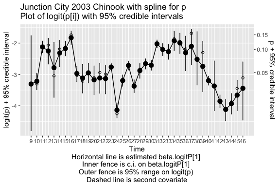

Estimates of logit(p)

```r
demo4.fit$plots$logitP.plot
```

Here is a plot of the estimated $logit(p)$’s with the fitted spline for the $p$’s:

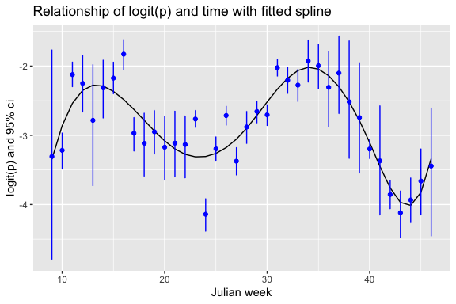

The underlying spline smooths the p’s somewhat, especially when the credible intervals are very wide (e.g. around julian weeks 37-40).

A summary of the posterior for each parameter is also available. In particular, here are the summary statistics on the posterior sample for the total number unmarked and total abundance:

```r
demo4.fit$summary[ row.names(demo4.fit$summary) %in% c("Ntot","Utot"),]
```

```
#>         mean       sd    2.5%     25%     50%     75%   97.5%     Rhat n.eff
#> Ntot 6245617 526927.4 5428102 5881117 6181515 6545797 7439444 1.003715   830
#> Utot 6195152 526927.4 5377637 5830652 6131050 6495332 7388979 1.003711   830
```

The estimated total abundance from $BTSPAS$ is 6,245,617 (SD 526,927 ) fish.

# 9 References

Bonner, S. J., & Schwarz, C. J. (2011). Smoothing population size estimates for Time-Stratified Mark–Recapture experiments Using Bayesian P-Splines. Biometrics, 67, 1498–1507. https://doi.org/10.1111/j.1541-0420.2011.01599.x

Schwarz, C. J., & Dempson, J. B. (1994). Mark-recapture estimation of a salmon smolt population. Biometrics, 50, 98–108.